# eBird Status and Trends

Maddee Wiggins (FlowWest)

2026-10-14

## Overview

[eBird Status and Trends](https://science.ebird.org/en/status-and-trends) provides modeled estimates of species distribution, relative abundance, and population trend, derived from eBird checklists and remotely sensed habitat covariates. Unlike the raw eBird observations used elsewhere in this package (`klamath_ebird`), these are effort-corrected model predictions on a regular grid, which makes them comparable across space rather than a reflection of where birders happened to go.

This document pulls two distinct products and clips both to the Klamath Basin boundary (`rivermile::klamath_hucs`):

1. **Status** — weekly relative abundance, count, and occurrence rasters (3 km resolution), 2023
2. **Trends** — modeled percent-per-year change in relative abundance (~27 km resolution), for 2012-2022.

```r
ebirdst_version()
```

```
## $status_version_year
## [1] 2023
##
## $trends_version_year
## [1] 2022
##
## $release_year
## [1] 2025
```

Note that the status and trends products are on **different release cycles** — the status estimates and the trends estimates are not from the same model year, so they should not be described as a single vintage.

### Access key

Status and Trends data require a free access key, requested at https://ebird.org/st/request. The key is a secret and should never be typed into a chunk, script, or anything that gets committed. Run this once, directly in the R console (not in this document):

```r
ebirdst::set_ebirdst_access_key("your-key-here")
```

That call writes `EBIRDST_KEY` into `~/.Renviron`, outside the project directory. From then on every R session — including this document — picks the key up automatically from the environment, so nothing in this file ever needs to reference it directly. (The console command itself still lands in your R history, so if that’s a concern, edit `~/.Renviron` directly instead of using the helper.)

## Study area

`rivermile::klamath_hucs` supplies the Klamath Basin outline used to clip the rasters and draw the maps.

```r
klamath_hucs <- rivermile::klamath_hucs
klamath_outline <- st_union(klamath_hucs)

glimpse(klamath_hucs)
```

```
## Rows: 12
## Columns: 3
## $ huc8     <chr> "18010203", "18010201", "18010202", "18010205", "18010207", "…
## $ name     <chr> "Upper Klamath Lake", "Williamson", "Sprague", "Butte", "Shas…
## $ geometry <POLYGON [°]> POLYGON ((-122.1347 42.9102..., POLYGON ((-121.6369 4…
```

Status values are summarized by wildlife refuge using `rivermile::klamath_refuges`, buffered 0.5 miles and named to match `area` in `klamath_ebird` and `piscivorous_waterbirds` (the same convention as `bird_data_synthesis.Rmd`).

```r
refuge_buffer_dist <- units::set_units(0.5, "mi")

klamath_refuges <- rivermile::klamath_refuges |>
  mutate(
    site = case_when(
      str_detect(orgname, "bear valley")   ~ "Bear Valley",
      str_detect(orgname, "clear lake")    ~ "Clear Lake",
      str_detect(orgname, "klamath marsh") ~ "Klamath Marsh",
      str_detect(orgname, "lower klamath") ~ "Lower Klamath - Sheepy",
      str_detect(orgname, "tule lake")     ~ "Tule Lake",
      str_detect(orgname, "upper klamath") ~ "Upper Klamath Lake"
    )
  ) |>
  select(site, orgname) |>
  st_buffer(dist = refuge_buffer_dist)

glimpse(klamath_refuges)
```

```
## Rows: 6
## Columns: 3
## $ site     <chr> "Bear Valley", "Clear Lake", "Klamath Marsh", "Lower Klamath …
## $ orgname  <chr> "bear valley national wildlife refuge", "clear lake national …
## $ geometry <MULTIPOLYGON [°]> MULTIPOLYGON (((-121.9524 4..., MULTIPOLYGON (((…
```

Both Status and Trends products are distributed on global equal-area grids, but not the same one — status rasters are Equal Earth (EPSG:8857) while the trends grid is sinusoidal. Rather than hard-coding either, the boundary is reprojected to whatever CRS the downloaded product reports. Reprojecting the vector rather than the raster matters: warping the raster would resample the estimates and distort the equal-area cells that the abundance values are defined on.

## Species

The focal species here are the three tracked by the multispecies subgroup. `ebirdst_runs` is the authoritative list of what is modeled, including whether a species has trends estimates at all.

```r
focal_species <- c("Cinnamon Teal", "Eared Grebe", "White-faced Ibis")

focal_runs <- ebirdst_runs |>
  filter(common_name %in% focal_species) |>
  glimpse()
```

```
## Rows: 3
## Columns: 30
## $ species_code                   <chr> "cintea", "eargre", "whfibi"
## $ scientific_name                <chr> "Spatula cyanoptera", "Podiceps nigrico…
## $ common_name                    <chr> "Cinnamon Teal", "Eared Grebe", "White-…
## $ is_resident                    <lgl> FALSE, FALSE, FALSE
## $ breeding_quality               <chr> "3", "2", "3"
## $ breeding_start                 <date> 2023-05-24, 2023-05-31, 2023-05-17
## $ breeding_end                   <date> 2023-07-26, 2023-08-02, 2023-07-05
## $ nonbreeding_quality            <chr> "3", "3", "3"
## $ nonbreeding_start              <date> 2023-12-06, 2023-12-27, 2023-11-22
## $ nonbreeding_end                <date> 2023-01-18, 2023-02-22, 2023-03-15
## $ postbreeding_migration_quality <chr> "3", "2", "3"
## $ postbreeding_migration_start   <date> 2023-08-02, 2023-08-09, 2023-07-12
## $ postbreeding_migration_end     <date> 2023-11-29, 2023-12-20, 2023-11-15
```

[output cut: 17 more lines]

```r
knitr::kable(focal_runs |>
               select(
                 common_name, species_code, is_resident,
                 breeding_quality, nonbreeding_quality,
                 has_trends, trends_season, trends_start_year, trends_end_year
               ), caption = "Status and Trends model coverage for the focal species")
```

Status and Trends model coverage for the focal species

| common_name | species_code | is_resident | breeding_quality | nonbreeding_quality | has_trends | trends_season | trends_start_year | trends_end_year |
| --- | --- | --- | --- | --- | --- | --- | --- | --- |
| Cinnamon Teal | cintea | FALSE | 3 | 3 | TRUE | breeding | 2012 | 2022 |
| Eared Grebe | eargre | FALSE | 2 | 3 | FALSE | NA | NA | NA |
| White-faced Ibis | whfibi | FALSE | 3 | 3 | TRUE | breeding | 2012 | 2022 |

Two things to note before going further:

- **Eared Grebe has no trends estimates** (`has_trends = FALSE`), so it appears in the status section but drops out of the trends section. Any species list used here should be filtered on `has_trends` rather than assumed complete.
- Model quality is rated per season on a 0-3 scale. These ratings should be checked before interpreting a surface, or the weekly values that fall in that season; a low rating means the model was poorly validated for that season.

## Status: weekly relative abundance, count, and occurrence

eBird Status models are fit to eBird checklists and environmental covariates, adjusted for observer effort, and predict for each of 52 weeks on a global grid what a standardized checklist would record: a 2 km, 1 hour Traveling Count by an expert observer, at the best time of day for the species. Three products are pulled, each the weekly median estimate, with `load_raster(period = "weekly")`:

| `product` | Cell value |
| --- | --- |
| `occurrence` | probability (0-1) that the species is reported |
| `count` | expected count, *given* that the species occurs |
| `abundance` | expected relative abundance, defined as occurrence × count |

```r
# Each 3 km weekly file is global (nine here); use "9km" or "27km" to download less.
status_resolution <- "3km"
status_products <- c("abundance", "count", "occurrence")

#' Load one weekly status product for a species and clip it to the Klamath Basin
clip_status_to_klamath <- function(species, product, resolution = status_resolution) {
  r <- load_raster(
    species,
    product    = product,
    period     = "weekly",
    resolution = resolution
  )

  # Reproject the boundary into the raster's own CRS, not the reverse.
  boundary <- st_transform(klamath_outline, terra::crs(r)) |> vect()

  r |>
    terra::crop(boundary) |>
    terra::mask(boundary)
}

# One pull per species x product, each kept as a 52-layer clipped raster.
status_weekly <- expand_grid(common_name = focal_species, product = status_products) |>
  mutate(raster = map2(common_name, product, clip_status_to_klamath))

# Every pull should return the full 52 weeks.
status_weekly |>
  mutate(
    n_weeks    = map_int(raster, terra::nlyr),
    first_week = map_chr(raster, \(r) names(r)[1]),
    last_week  = map_chr(raster, \(r) names(r)[terra::nlyr(r)])
  ) |>
  select(-raster)
```

```
## # A tibble: 9 × 5
##   common_name      product    n_weeks first_week last_week
##   <chr>            <chr>        <int> <chr>      <chr>
## 1 Cinnamon Teal    abundance       52 2023-01-04 2023-12-27
## 2 Cinnamon Teal    count           52 2023-01-04 2023-12-27
## 3 Cinnamon Teal    occurrence      52 2023-01-04 2023-12-27
## 4 Eared Grebe      abundance       52 2023-01-04 2023-12-27
## 5 Eared Grebe      count           52 2023-01-04 2023-12-27
## 6 Eared Grebe      occurrence      52 2023-01-04 2023-12-27
## 7 White-faced Ibis abundance       52 2023-01-04 2023-12-27
## 8 White-faced Ibis count           52 2023-01-04 2023-12-27
## 9 White-faced Ibis occurrence      52 2023-01-04 2023-12-27
```

Maps use eBird’s seasonal mean of weekly abundance (four panels per species); `ebird_status` itself is built from the weekly pulls.

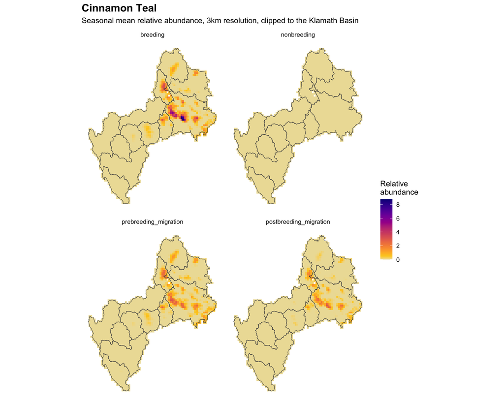

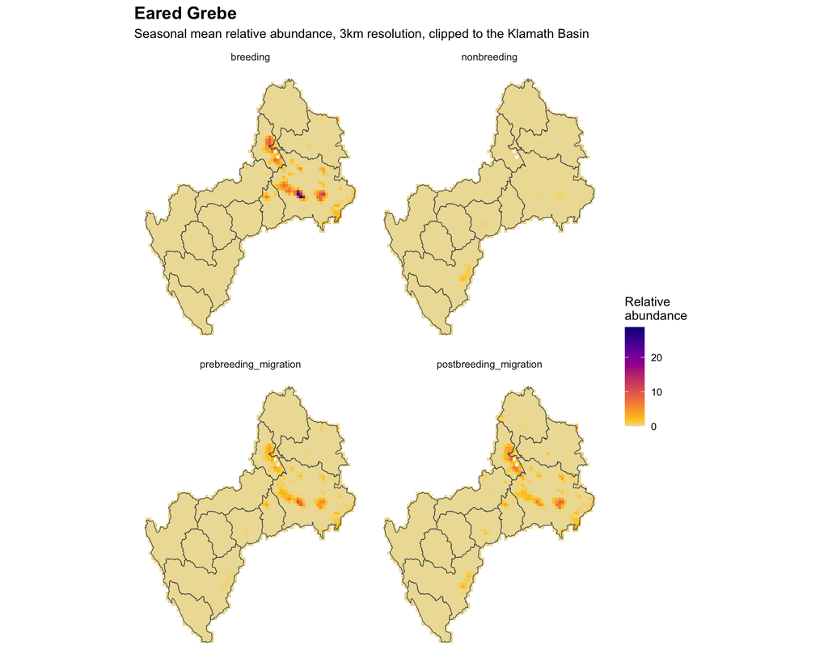

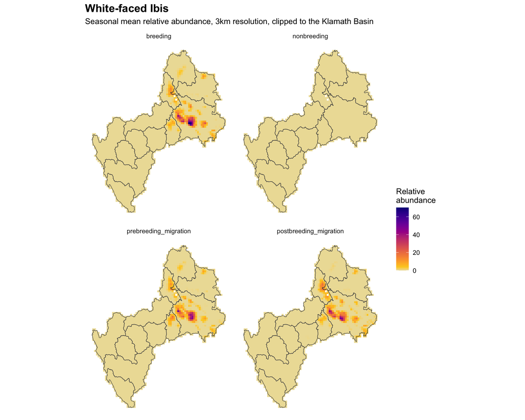

```r
display_crs <- "EPSG:32610"
display_buffer <- units::set_units(15, "km")

plot_status <- function(species, resolution = status_resolution) {
  r <- load_raster(
    species,
    product    = "abundance",
    period     = "seasonal",
    metric     = "mean",
    resolution = resolution
  )

  # Loose crop, still in the native CRS, just to keep the reprojection cheap.
  wide_boundary <- st_buffer(klamath_outline, display_buffer) |>
    st_transform(terra::crs(r)) |>
    vect()
  r_wide <- terra::crop(r, wide_boundary)

  # Reproject before the tight crop - see note above.
  r_disp <- terra::project(r_wide, display_crs, method = "bilinear")

  # Only now compute the tight boundary, directly in the display CRS.
  tight_boundary <- st_transform(klamath_outline, display_crs) |> vect()
  r_disp <- r_disp |> terra::crop(tight_boundary) |> terra::mask(tight_boundary)

  ggplot() +
    geom_spatraster(data = r_disp) +
    geom_sf(data = st_transform(klamath_hucs, display_crs),
            fill = NA, color = "grey30", linewidth = 0.25) +
    facet_wrap(~ lyr) +
    scale_fill_gradientn(
      colours = ebirdst_palettes(20, type = "weekly"),
      na.value = "transparent",
      name = "Relative\nabundance"
    ) +
    labs(
      title = species,
      subtitle = paste0("Seasonal mean relative abundance, ", status_resolution,
                        " resolution, clipped to the Klamath Basin")
    ) +
    theme(axis.text = element_blank(), panel.grid = element_blank())
}

walk(focal_species, \(sp) print(plot_status(sp)))
```

### How `ebird_status` is calculated

1. Each species × product pull is a 52-layer raster, one layer per week, cropped and masked to the basin.
2. For each refuge and week, `mean_value` is the mean of the cell values whose centre falls inside the refuge (0.5-mile buffer). Cells with no estimate are ignored; a refuge with none is `NA`.
3. The species × product × refuge × week rows are bound into one table.

### What `mean_value` means

- **`abundance`**: relative to the standardized checklist — not a density or a number of birds. Compare across weeks or refuges for one species, not between species (see Caveats); don’t sum.
- **`count`**: same scale caveat. Every cell is weighted equally, including cells where the species is unlikely, so it is not the count where the species is actually found.
- **`occurrence`**: the average probability of reporting the species at a random spot in the refuge, not the probability it occurs somewhere in it.
- `abundance` is occurrence × count in each cell, but only approximately, since each weekly layer is its own median estimate.
- `week` is eBird’s week number (1-52) and `month` is the calendar month of that week’s middle date, so each month has 4-5 weeks. The release’s year (2023) is not carried; read `week` as a position in the annual cycle.

```r
#' Mean of every weekly layer within each refuge, long: one row per refuge x week
summarise_by_refuge <- function(r, species, status_product) {
  refuges_prj <- st_transform(klamath_refuges, terra::crs(r))

  terra::extract(r, vect(refuges_prj), fun = mean, na.rm = TRUE, ID = FALSE) |>
    as_tibble() |>
    bind_cols(area = refuges_prj$site) |>
    pivot_longer(-area, names_to = "week_date", values_to = "mean_value") |>
    mutate(
      common_name = species,
      product     = status_product,
      # Layer names are the week-midpoint dates. Keep the week's position in
      # the year (1-52) and the month of its middle date; drop the year, which
      # is only the release's prediction year.
      week        = match(week_date, names(r)),
      month       = as.integer(lubridate::month(as.Date(week_date))),
      # A refuge with no estimated cell (outside the modeled range) is NaN.
      mean_value  = if_else(is.nan(mean_value), NA_real_, mean_value)
    )
}

ebird_status <- status_weekly |>
  pmap(\(common_name, product, raster) summarise_by_refuge(raster, common_name, product)) |>
  list_rbind() |>
  select(common_name, product, area, week, month, mean_value)
```

```r
ebird_status |>
  filter(product == "abundance", mean_value > 0) |>
  slice_max(mean_value, n = 1, with_ties = FALSE, by = c(common_name, area)) |>
  transmute(
    common_name, area,
    peak_week      = week,
    peak_month     = month.abb[month],
    peak_abundance = mean_value
  ) |>
  arrange(common_name, desc(peak_abundance)) |>
  knitr::kable(
    digits = 3,
    col.names = c("Species", "Refuge", "Peak week", "Peak month", "Peak abundance"),
    caption = "Week of peak mean relative abundance, by wildlife refuge (refuges with zero abundance in every week are omitted)"
  )
```

Week of peak mean relative abundance, by wildlife refuge (refuges with zero abundance in every week are omitted)

| Species | Refuge | Peak week | Peak month | Peak abundance |
| --- | --- | --- | --- | --- |
| Cinnamon Teal | Tule Lake | 27 | Jul | 7.211 |
| Cinnamon Teal | Lower Klamath - Sheepy | 32 | Aug | 5.040 |
| Cinnamon Teal | Upper Klamath Lake | 16 | Apr | 4.401 |
| Cinnamon Teal | Clear Lake | 32 | Aug | 3.877 |
| Cinnamon Teal | Klamath Marsh | 16 | Apr | 1.556 |
| Eared Grebe | Tule Lake | 27 | Jul | 15.154 |
| Eared Grebe | Upper Klamath Lake | 28 | Jul | 10.878 |
| Eared Grebe | Clear Lake | 30 | Jul | 9.952 |
| Eared Grebe | Lower Klamath - Sheepy | 27 | Jul | 5.250 |
| Eared Grebe | Klamath Marsh | 42 | Oct | 0.250 |
| White-faced Ibis | Tule Lake | 28 | Jul | 72.061 |
| White-faced Ibis | Lower Klamath - Sheepy | 28 | Jul | 52.828 |
| White-faced Ibis | Upper Klamath Lake | 28 | Jul | 29.466 |
| White-faced Ibis | Clear Lake | 30 | Jul | 18.335 |
| White-faced Ibis | Klamath Marsh | 17 | Apr | 2.572 |

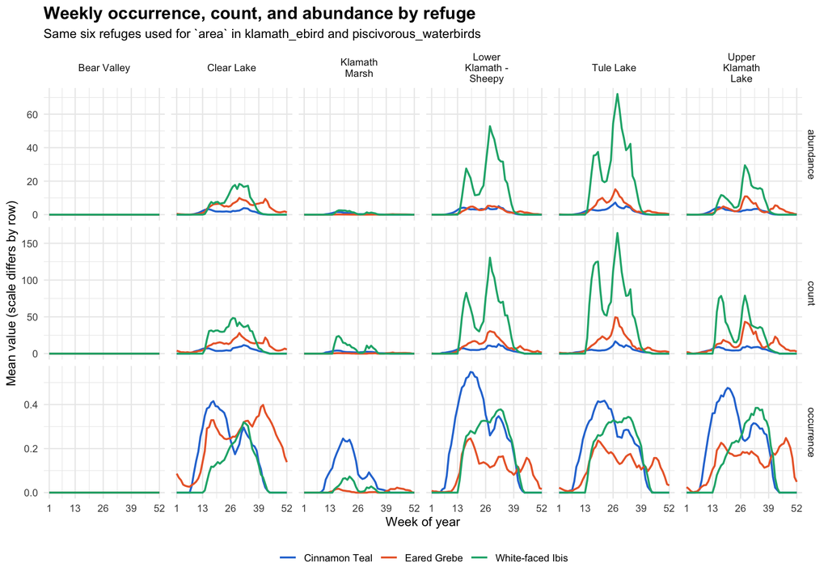

```r
status_pal <- c("Cinnamon Teal" = "#2a78d6", "Eared Grebe" = "#eb6834",
                "White-faced Ibis" = "#1baf7a")

# Occurrence is a probability, count and abundance are on different scales, so
# each product gets its own y-axis.
ebird_status |>
  filter(!is.na(mean_value)) |>
  mutate(product = factor(product, levels = status_products)) |>
  ggplot(aes(x = week, y = mean_value, color = common_name)) +
  geom_line(linewidth = 0.8) +
  facet_grid(
    product ~ area, scales = "free_y",
    labeller = labeller(area = label_wrap_gen(12))
  ) +
  scale_x_continuous(breaks = c(1, 13, 26, 39, 52)) +
  scale_color_manual(values = status_pal, name = NULL) +
  labs(
    title = "Weekly occurrence, count, and abundance by refuge",
    subtitle = "Same six refuges used for `area` in klamath_ebird and piscivorous_waterbirds",
    x = "Week of year", y = "Mean value (scale differs by row)"
  ) +
  theme(legend.position = "bottom")
```

## Save Data Object

```r
ebird_status |> glimpse()
```

```
## Rows: 2,808
## Columns: 6
## $ common_name <chr> "Cinnamon Teal", "Cinnamon Teal", "Cinnamon Teal", "Cinnam…
## $ product     <chr> "abundance", "abundance", "abundance", "abundance", "abund…
## $ area        <chr> "Bear Valley", "Bear Valley", "Bear Valley", "Bear Valley"…
## $ week        <int> 1, 2, 3, 4, 5, 6, 7, 8, 9, 10, 11, 12, 13, 14, 15, 16, 17,…
## $ month       <int> 1, 1, 1, 1, 2, 2, 2, 2, 3, 3, 3, 3, 3, 4, 4, 4, 4, 5, 5, 5…
## $ mean_value  <dbl> 0, 0, 0, 0, 0, 0, 0, 0, 0, 0, 0, 0, 0, 0, 0, 0, 0, 0, 0, 0…
```

```r
usethis::use_data(ebird_status, overwrite = TRUE)
```

## Trends: percent change per year

Trends are estimated differently from status. Rather than modeling absolute abundance in a single year, the trends model finds pairs of checklists that are close in location and similar in habitat and survey effort but taken in different years, and asks how relative abundance differed between the two years of each pair. Averaging that year-over-year change across many such pairs within a grid cell yields a percent-per-year trend for the cell, along with a confidence interval. Because it relies on paired comparisons rather than a single-year surface, this product is modeled on a coarser (~27 km) grid than status, and only for the 2012-2022 breeding season here. Trend estimates arrive as a data frame of grid cell centres with longitude/latitude in EPSG:4326, so the clip is a spatial filter of points rather than a raster mask.

```r
trends_species <- focal_runs |>
  filter(has_trends) |>
  pull(common_name)

trends_species
```

```
## [1] "Cinnamon Teal"    "White-faced Ibis"
```

```r
walk(trends_species, ebirdst_download_trends)
```

```r
trends_raw <- set_names(trends_species) |>
  map(\(sp) load_trends(sp)) |>
  list_rbind(names_to = "common_name")

# Cell centres are lon/lat, so filter in 4326 against the basin outline.
trends_sf <- trends_raw |>
  st_as_sf(coords = c("longitude", "latitude"), crs = 4326, remove = FALSE)

trends_klamath <- trends_sf |>
  st_filter(st_transform(klamath_outline, 4326), .predicate = st_intersects)

# How many 27 km cells actually fall inside the basin?
trends_klamath |>
  st_drop_geometry() |>
  count(common_name, season, name = "n_cells")
```

```
## # A tibble: 2 × 3
##   common_name      season   n_cells
##   <chr>            <chr>      <int>
## 1 Cinnamon Teal    breeding      30
## 2 White-faced Ibis breeding      22
```

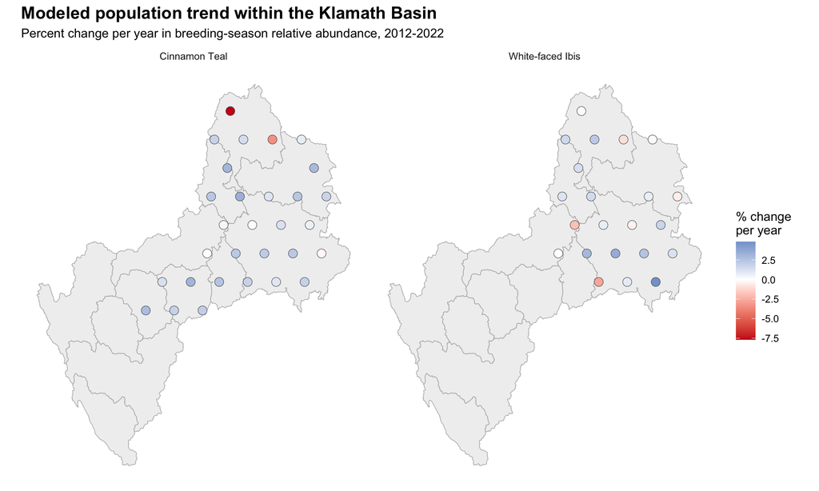

```r
# ebirdst's own trends palette runs red (decline) -> white (no change) ->
# blue (increase). Keep that direction: it is the convention every published
# Status and Trends map uses, and flipping it would invert the reading.
trends_pal <- ebirdst_palettes(3, type = "trends")

ggplot() +
  geom_sf(data = st_transform(klamath_hucs, 4326), fill = "grey94", color = "grey70",
          linewidth = 0.25) +
  # shape 21 keeps near-zero (near-white) cells visible against the basin.
  geom_sf(data = trends_klamath, aes(fill = abd_ppy),
          shape = 21, color = "grey35", stroke = 0.3, size = 3.5) +
  facet_wrap(~ common_name) +
  scale_fill_gradient2(
    low = trends_pal[1], mid = trends_pal[2], high = trends_pal[3],
    midpoint = 0,
    name = "% change\nper year"
  ) +
  labs(
    title = "Modeled population trend within the Klamath Basin",
    subtitle = "Percent change per year in breeding-season relative abundance, 2012-2022",
    x = NULL, y = NULL
  ) +
  theme(axis.text = element_blank(), panel.grid = element_blank())
```

A diverging scale centred on zero is used deliberately: the quantity has a meaningful neutral point (no change), and the two arms read as opposite directions — **red is decline, blue is increase**, following eBird’s own convention. Cell-level estimates carry wide confidence intervals, so the summary below reports them rather than the point estimate alone.

```r
trends_klamath |>
  st_drop_geometry() |>
  summarise(
    n_cells         = n(),
    median_ppy      = median(abd_ppy),
    mean_ppy        = mean(abd_ppy),
    median_ppy_low  = median(abd_ppy_lower),
    median_ppy_high = median(abd_ppy_upper),
    cells_declining = sum(abd_ppy < 0),
    .by = c(common_name, season)
  ) |>
  arrange(median_ppy) |>
  knitr::kable(digits = 3, caption = "Trend summary for cells intersecting the Klamath Basin")
```

Trend summary for cells intersecting the Klamath Basin

| common_name | season | n_cells | median_ppy | mean_ppy | median_ppy_low | median_ppy_high | cells_declining |
| --- | --- | --- | --- | --- | --- | --- | --- |
| White-faced Ibis | breeding | 22 | 0.971 | 0.911 | -1.361 | 2.806 | 7 |
| Cinnamon Teal | breeding | 30 | 1.846 | 1.194 | -0.454 | 3.713 | 6 |

Assigning trend cells to individual subbasins is possible but marginal at this resolution: a single 27 km cell is comparable in size to the smaller HUC8s, so a per-subbasin trend would mostly reflect which cell centre landed where. Basin-wide summaries are the appropriate grain for this product.

### `ebird_trends`: trends by refuge

`ebird_trends` mirrors `ebird_status`: long format, one row per species × metric × refuge, with `area` matching `klamath_ebird$area`. Each cell has a single estimate for the breeding season over the full 2012-2022 window of the current Trends release, and there is no year-by-year series, so `start_year` and `end_year` take the place of `week`. Eared Grebe has no trends and is excluded.

It follows eBird’s regional-trend method (abundance-weighted, computed per ensemble fold), adapted so each cell counts in proportion to how much of it the refuge covers:

1. For each refuge, find the 27 km cells it overlaps and the share of each cell it covers.
2. In each of the 100 ensemble folds, the refuge’s `abd_ppy` is sum(overlap × `abd` × `abd_ppy`) / sum(overlap × `abd`) over those cells.
3. `abd_ppy` is the median across folds; `abd_ppy_lower` and `abd_ppy_upper` are the 10th and 90th percentiles (an 80% interval).
4. `abd` is the overlap-weighted mean of the cells’ relative abundance at the middle of the trend period.

`abd_ppy` is the percent change in relative abundance per year; negative is a decline. Averaging cell-level interval bounds would not give a valid refuge interval, which is why folds are used. A 27 km cell (about 711 km²) is far larger than a refuge (34-325 km²), and each refuge overlaps only 2-4 cells, so the values describe the surrounding landscape more than the refuge itself.

```r
#' Refuge-level trend for one species, from the 27 km cell and fold estimates
trends_by_refuge <- function(species) {
  cells <- load_trends(species)
  folds <- load_trends(species, fold_estimates = TRUE)

  # Raster of cell ids on the trends grid, to get each refuge's overlap with
  # each cell.
  grid <- rasterize_trends(cells, layers = "abd", trim = FALSE)
  cell_ids <- vect(
    cells[c("longitude", "latitude", "srd_id")],
    geom = c("longitude", "latitude"), crs = "epsg:4326"
  ) |>
    terra::project(terra::crs(grid)) |>
    terra::rasterize(grid, field = "srd_id")
  names(cell_ids) <- "srd_id"  # rasterize() names the layer "last"

  # Share of each cell covered by each refuge.
  overlap <- terra::extract(
    cell_ids, vect(st_transform(klamath_refuges, terra::crs(grid))),
    exact = TRUE, ID = TRUE
  ) |>
    as_tibble() |>
    filter(!is.na(srd_id)) |>
    transmute(area = klamath_refuges$site[ID], srd_id, weight = fraction)

  # A cell can overlap more than one refuge, hence many-to-many.
  ppy <- folds |>
    inner_join(overlap, by = "srd_id", relationship = "many-to-many") |>
    summarise(ppy = sum(weight * abd * abd_ppy) / sum(weight * abd), .by = c(area, fold)) |>
    summarise(
      abd_ppy       = median(ppy),
      abd_ppy_lower = quantile(ppy, 0.1, names = FALSE),
      abd_ppy_upper = quantile(ppy, 0.9, names = FALSE),
      .by = area
    )

  abd <- cells |>
    inner_join(overlap, by = "srd_id", relationship = "many-to-many") |>
    summarise(abd = sum(weight * abd) / sum(weight), .by = area)

  full_join(ppy, abd, by = "area") |>
    mutate(
      common_name = species,
      season      = cells$season[1],
      start_year  = cells$start_year[1],
      end_year    = cells$end_year[1]
    )
}

ebird_trends <- trends_species |>
  map(trends_by_refuge) |>
  list_rbind() |>
  pivot_longer(
    c(abd_ppy, abd_ppy_lower, abd_ppy_upper, abd),
    names_to = "metric", values_to = "value"
  ) |>
  select(common_name, metric, area, season, start_year, end_year, value) |>
  glimpse()
```

```
## Rows: 48
## Columns: 7
## $ common_name <chr> "Cinnamon Teal", "Cinnamon Teal", "Cinnamon Teal", "Cinnam…
## $ metric      <chr> "abd_ppy", "abd_ppy_lower", "abd_ppy_upper", "abd", "abd_p…
## $ area        <chr> "Klamath Marsh", "Klamath Marsh", "Klamath Marsh", "Klamat…
## $ season      <chr> "breeding", "breeding", "breeding", "breeding", "breeding"…
## $ start_year  <int> 2012, 2012, 2012, 2012, 2012, 2012, 2012, 2012, 2012, 2012…
## $ end_year    <int> 2022, 2022, 2022, 2022, 2022, 2022, 2022, 2022, 2022, 2022…
## $ value       <dbl> -0.9471991, -2.5525454, 0.2228120, 0.1927713, 3.1312384, 1…
```

```r
usethis::use_data(ebird_trends, overwrite = TRUE)
```

## Caveats

- **Model output, not observation.** These are predictions from a model fit to eBird data. They are effort-corrected, which is precisely why they are useful alongside `klamath_ebird`, but they inherit the assumptions of the underlying model.
- **Don’t compare relative abundance between species.** eBird advises against it “because the percentages of undetected individuals will differ among species” ([eBird Status and Trends FAQ](https://science.ebird.org/status-and-trends/faq#abundance)). Compare one species across weeks or refuges. The plots draw species together for layout only.
- **Check seasonal quality ratings.** A season rated 0-1 should not be interpreted, and that applies to the weeks that fall inside it. The species table above shows each season’s rating, and `ebirdst_runs` gives the season dates, which are not carried in `ebird_status`.
- **Resolution mismatch.** Status is clipped at 3 km, trends at ~27 km. The two are not directly comparable cell-for-cell, and the basin contains relatively few trend cells.
- **Small refuges.** Each refuge mean uses the 3 km cells whose centre falls inside the buffered refuge, so cells straddling the edge are in or out whole. Refuges are small relative to that grid: Bear Valley has only about 3 such cells (about 34 km² with the buffer), versus roughly 20-37 for the other five, so its mean in particular is indicative rather than precise.
- **Trends are breeding-season only** for these species, so they say nothing about the migratory and wintering periods that the status surfaces do cover.

## Citation

Data products must be cited; `ebirdst` bundles the current citation.

```r
citation("ebirdst")
```